title: “BA Assignment 3” author: “Nikeeta Rani” date: “2024-04-20”

# Executive Summary:

### Introduction

This document consists of comprehensive analysis of residential home sales price.The data set consisted of 12 variables in total. 11 variables which were used as an input to predict the sales price (the output).

The input variables were: 1) Finished square feet 2) Number of bedrooms 3) Number of bathrooms 4) Air conditioning 5) Garage size 6) Pool 7) Year BUilt 8) Quality of Construction 9) Style 10) Lot size 11) Adjacent to highway

The output Variable was: Sales Prices

### Purpose

The purpose of this document is to identify the relationship between Dependent Variable (Sales prices) and independent variables by using multiple linear regression model and identify how significant the importance of each input variable is (in th presence of other variables) in the model.

### Hypothesis Testing

We form the Null and Alternative of the the complete model and of the individual coefficients.

#### For Complete Model:

Ho : B1=B2=B3=B4=B5=B6=B7=B8=B9=B10=B11 = 0 Ha : Not all Bs = 0

Here, Null Hypothesis explains that all input variables have no impact on the Sales Price. And Alternative Hypothesis Explains that at least one of the input variable’s slope is not zero.

#### For Individual Coefficients:

Ho : (Bn) = 0 Ha : (Bn) = 0

Here, Null Hypothesis explains that there is no relationship between the independent variable on the Sales Prices. And Alternative Hypothesis Explains that there is a relationship between X and Y.

### R-Square:

First we will discuss which variables is explaining the highest variability or change in the sales price.For this we have calculated R-Square

Talking about the R-square of the overall model, 77.5% of the variability in the sales price if explained by the all the input variables.

### Multiple Linear Regression Model - All Variables excluding Quality of Construction

After constructing the multiple linear regression model. We obtained the following equation

Sales Price = -3.503e+06 +(1.485e+02 * SqFt )+(-1.186e+04 * Bedrooms )+(1.012e+04 * Bathrooms )+(-3.499e+03 * AC )+(1.806e+04 * Garage )+(8.942e+03 * Pool )+(1.743+03 * Year )+(-1.053e+04 * Style )+(1.330e+00 * Lotsize )+(-3.883e+04 * Hwy)

The above equation indicates that the House price will increase with every additional units of Sqft, Bathrooms, garage , Pool and Lotsize and House price will decrease with every additional Unit of Bedrooms, AC, Style and if the house is adjacent to highway. These variables are positively/negatively impacting the output considering all other input variables are present in the model, which means that the effect of all independent variable s dependent upon what other variables are there in the model.

### Hypothesis Testing

#### P-Value (For overall Model)

Ho : B1=B2=B3=B4=B5=B6=B7=B8=B9=B10=B11 = 0 Ha : Not all Bs = 0

At 0.05 Significance Level: As our P value is smaller that alpha i.e 0.05, we will reject the null hypothesis.But there is a chance of 5% that we are making type 1 error. which means that although we have concluded alternative hypothesis, but in reality null hypothesis is true.

#### P-Value (For Individual Coefficients)

Ho : B(n) = 0 Ha : B(n) = 0

At 0.05 Significance level, P-value of AC, Pool and Hwy seems greater than alpha of 0.05. We will accept the null hypothesis that these variables individually do not form the linear relationship with Sales Prices. Here there are chances of making Type 2 error, which means that although we are concluding Null Hypothesis, but in reality Alternative Hypothesis can be true.

P-value of all other variables is smaller than alpha, hence reject the null in facor of the alternative hypothesis that these variable do create a linear relation with the Sales pRICES. Here are 5% chances of Type 1 error.

### Multiple Linear Regression Model - Excluding Insignificant Variables

After analyzing P-Value, we observed that AC and Pool are not significant to form a linear relationship with Sales price. Then, we created multiple linear model by first excluding AC because it has the high P-value. We did not exclude both the variables at the same time because all the independent variables are depend on the other, which means that there were chances that Pool would have become significant after removing AC.

### Analysis of Graphs

We plotted the graphs for residuals against fitted values (Predicted Values) to check if our following assumption has been satisfied or not:

1. NID(0, Sigma Squared): which means normal, Independent with the mean of zero, and the variance of sigma squared. This is explaining the distribution of residuals that it should follow the above properties.

On Y Axis we plotted Residuals, from wich we observed that on average, the value of the residuals is zero and all the data points are randomly distributed along the mean line which means that some data points are above the line and some are below the line with no clear pattern showing the linear relation. We also observed that it is violating the assumption of constant variance (Sigma Squared) because there is a less variation in residuals at the beginning (Left) and more variation in residuals along the line (Right).

# Loading Required Packages

```r
library(stats)
```

# Loading the data

```r
Sale_Price<-read.csv("C:/Users/hp/Desktop/KSU/Business Analytics/Assignment 3/APPENC07.csv")
```

# Indentifying R-Sqaure for each independent Variable

```r
Sqft<- lm(SalesPrice~SqFt, Sale_Price)
Bedrooms<- lm(SalesPrice~Bedrooms, Sale_Price)
Bathrooms<- lm(SalesPrice~Bathrooms, Sale_Price)
AC <- lm(SalesPrice~AC, Sale_Price)
Garage<- lm(SalesPrice~Garage, Sale_Price)
Pool <- lm(SalesPrice~Pool, Sale_Price)
Year <- lm(SalesPrice~Year, Sale_Price)
Quality <- lm(SalesPrice~Qualtiy, Sale_Price)
Style <- lm(SalesPrice~Style, Sale_Price)
LotSize <- lm(SalesPrice~LotSize, Sale_Price)
Highway<- lm(SalesPrice~Hwy, Sale_Price)
```

```r
summary( Sqft)$r.squared
```

```
## [1] 0.6715312
```

```r
summary(Bedrooms)$r.squared
```

```
## [1] 0.1708366
```

```r
summary( Bathrooms)$r.squared
```

```
## [1] 0.4674257
```

```r
summary(AC)$r.squared
```

```
## [1] 0.08328779
```

```r
summary(Garage)$r.squared
```

```
## [1] 0.333837
```

```r
summary(Pool)$r.squared
```

```
## [1] 0.02149497
```

```r
summary(Year)$r.squared
```

```
## [1] 0.3085985
```

```r
summary(Quality)$r.squared
```

```
## [1] 0.5746828
```

```r
summary(Style)$r.squared
```

```
## [1] 0.1278015
```

```r
summary(LotSize)$r.squared
```

```
## [1] 0.05025152
```

```r
summary(Highway)$r.squared
```

```
## [1] 0.002597759
```

# Constructing Multiple Linear Regression Model

```r
regression_Model<- lm(SalesPrice ~ SqFt+Bedrooms+Bathrooms+AC+Garage+Pool+Year+Style+LotSize+Hwy, Sale_Price)
summary(regression_Model)
```

```
##
## Call:
## lm(formula = SalesPrice ~ SqFt + Bedrooms + Bathrooms + AC +
##     Garage + Pool + Year + Style + LotSize + Hwy, data = Sale_Price)
##
## Residuals:
##     Min      1Q  Median      3Q     Max
## -203238  -34086   -5107   26437  283244
##
## Coefficients:
##               Estimate Std. Error t value Pr(>|t|)
## (Intercept) -3.503e+06  4.153e+05  -8.435 3.42e-16 ***
## SqFt         1.485e+02  7.436e+00  19.968  < 2e-16 ***
## Bedrooms    -1.186e+04  3.628e+03  -3.270  0.00115 **
## Bathrooms    1.012e+04  4.655e+03   2.174  0.03020 *
## AC          -3.499e+03  8.800e+03  -0.398  0.69110
## Garage       1.806e+04  5.642e+03   3.201  0.00146 **
## Pool         8.942e+03  1.170e+04   0.764  0.44526
## Year         1.743e+03  2.144e+02   8.128 3.31e-15 ***
## Style       -1.053e+04  1.480e+03  -7.116 3.78e-12 ***
## LotSize      1.330e+00  2.669e-01   4.984 8.53e-07 ***
## Hwy         -3.883e+04  2.042e+04  -1.902  0.05780 .
## ---
## Signif. codes:  0 '***' 0.001 '**' 0.01 '*' 0.05 '.' 0.1 ' ' 1
##
## Residual standard error: 66070 on 511 degrees of freedom
## Multiple R-squared:  0.775,  Adjusted R-squared:  0.7706
## F-statistic:   176 on 10 and 511 DF,  p-value: < 2.2e-16
```

```r
anova(regression_Model)
```

```
## Analysis of Variance Table
##
## Response: SalesPrice
##            Df     Sum Sq    Mean Sq   F value    Pr(>F)
## SqFt        1 6.6555e+12 6.6555e+12 1524.8408 < 2.2e-16 ***
## Bedrooms    1 2.7613e+10 2.7613e+10    6.3263  0.012202 *
## Bathrooms   1 1.4271e+11 1.4271e+11   32.6964 1.835e-08 ***
## AC          1 3.3417e+10 3.3417e+10    7.6562  0.005863 **
## Garage      1 2.0019e+11 2.0019e+11   45.8657 3.491e-11 ***
## Pool        1 1.2314e+08 1.2314e+08    0.0282  0.866676
## Year        1 2.3521e+11 2.3521e+11   53.8890 8.414e-13 ***
## Style       1 2.6761e+11 2.6761e+11   61.3112 2.833e-14 ***
## LotSize     1 1.0241e+11 1.0241e+11   23.4629 1.691e-06 ***
## Hwy         1 1.5782e+10 1.5782e+10    3.6158  0.057796 .
## Residuals 511 2.2304e+12 4.3647e+09
## ---
## Signif. codes:  0 '***' 0.001 '**' 0.01 '*' 0.05 '.' 0.1 ' ' 1
```

# Final Model:

### First Excluding AC variable as it has the highest P-Value

```r
Final_Model_1<- lm(SalesPrice ~ SqFt+Bedrooms+Bathrooms+Garage+Pool+Year+Style+LotSize+Hwy, Sale_Price)
summary(Final_Model_1)
```

```
##
## Call:
## lm(formula = SalesPrice ~ SqFt + Bedrooms + Bathrooms + Garage +
##     Pool + Year + Style + LotSize + Hwy, data = Sale_Price)
##
## Residuals:
##     Min      1Q  Median      3Q     Max
## -202845  -34277   -5351   26332  283795
##
## Coefficients:
##               Estimate Std. Error t value Pr(>|t|)
## (Intercept) -3.463e+06  4.023e+05  -8.608  < 2e-16 ***
## SqFt         1.485e+02  7.429e+00  19.994  < 2e-16 ***
## Bedrooms    -1.198e+04  3.613e+03  -3.317 0.000975 ***
## Bathrooms    9.991e+03  4.640e+03   2.153 0.031786 *
## Garage       1.777e+04  5.590e+03   3.179 0.001570 **
## Pool         8.733e+03  1.168e+04   0.747 0.455121
## Year         1.721e+03  2.072e+02   8.306 8.89e-16 ***
## Style       -1.051e+04  1.478e+03  -7.111 3.89e-12 ***
## LotSize      1.344e+00  2.647e-01   5.077 5.39e-07 ***
## Hwy         -3.850e+04  2.039e+04  -1.888 0.059564 .
## ---
## Signif. codes:  0 '***' 0.001 '**' 0.01 '*' 0.05 '.' 0.1 ' ' 1
##
## Residual standard error: 66010 on 512 degrees of freedom
## Multiple R-squared:  0.7749, Adjusted R-squared:  0.7709
## F-statistic: 195.8 on 9 and 512 DF,  p-value: < 2.2e-16
```

```r
anova(Final_Model_1)
```

```
## Analysis of Variance Table
##
## Response: SalesPrice
##            Df     Sum Sq    Mean Sq   F value    Pr(>F)
## SqFt        1 6.6555e+12 6.6555e+12 1527.3523 < 2.2e-16 ***
## Bedrooms    1 2.7613e+10 2.7613e+10    6.3367   0.01213 *
## Bathrooms   1 1.4271e+11 1.4271e+11   32.7502 1.786e-08 ***
## Garage      1 2.2499e+11 2.2499e+11   51.6318 2.379e-12 ***
## Pool        1 2.2339e+08 2.2339e+08    0.0513   0.82097
## Year        1 2.4107e+11 2.4107e+11   55.3228 4.341e-13 ***
## Style       1 2.6636e+11 2.6636e+11   61.1275 3.070e-14 ***
## LotSize     1 1.0586e+11 1.0586e+11   24.2945 1.118e-06 ***
## Hwy         1 1.5536e+10 1.5536e+10    3.5653   0.05956 .
## Residuals 512 2.2311e+12 4.3575e+09
## ---
## Signif. codes:  0 '***' 0.001 '**' 0.01 '*' 0.05 '.' 0.1 ' ' 1
```

### Second Excluding Pool variable as it has the highest P-Value

```r
Final_Model_2<- lm(SalesPrice ~ SqFt+Bedrooms+Bathrooms+Garage+Year+Style+LotSize+Hwy, Sale_Price)
summary(Final_Model_2)
```

```
##
## Call:
## lm(formula = SalesPrice ~ SqFt + Bedrooms + Bathrooms + Garage +
##     Year + Style + LotSize + Hwy, data = Sale_Price)
##
## Residuals:
##     Min      1Q  Median      3Q     Max
## -195944  -34236   -5190   25967  282145
##
## Coefficients:
##               Estimate Std. Error t value Pr(>|t|)
## (Intercept) -3.443e+06  4.012e+05  -8.581  < 2e-16 ***
## SqFt         1.488e+02  7.418e+00  20.059  < 2e-16 ***
## Bedrooms    -1.191e+04  3.610e+03  -3.299  0.00104 **
## Bathrooms    1.034e+04  4.615e+03   2.240  0.02551 *
## Garage       1.790e+04  5.585e+03   3.205  0.00143 **
## Year         1.710e+03  2.066e+02   8.278 1.09e-15 ***
## Style       -1.056e+04  1.475e+03  -7.156 2.89e-12 ***
## LotSize      1.326e+00  2.635e-01   5.032 6.71e-07 ***
## Hwy         -3.885e+04  2.037e+04  -1.907  0.05710 .
## ---
## Signif. codes:  0 '***' 0.001 '**' 0.01 '*' 0.05 '.' 0.1 ' ' 1
##
## Residual standard error: 65980 on 513 degrees of freedom
## Multiple R-squared:  0.7746, Adjusted R-squared:  0.7711
## F-statistic: 220.4 on 8 and 513 DF,  p-value: < 2.2e-16
```

```r
anova(Final_Model_2)
```

```
## Analysis of Variance Table
##
## Response: SalesPrice
##            Df     Sum Sq    Mean Sq   F value    Pr(>F)
## SqFt        1 6.6555e+12 6.6555e+12 1528.6673 < 2.2e-16 ***
## Bedrooms    1 2.7613e+10 2.7613e+10    6.3422   0.01209 *
## Bathrooms   1 1.4271e+11 1.4271e+11   32.7784 1.760e-08 ***
## Garage      1 2.2499e+11 2.2499e+11   51.6763 2.325e-12 ***
## Year        1 2.3981e+11 2.3981e+11   55.0804 4.840e-13 ***
## Style       1 2.6733e+11 2.6733e+11   61.4019 2.702e-14 ***
## LotSize     1 1.0366e+11 1.0366e+11   23.8082 1.423e-06 ***
## Hwy         1 1.5830e+10 1.5830e+10    3.6359   0.05710 .
## Residuals 513 2.2335e+12 4.3538e+09
## ---
## Signif. codes:  0 '***' 0.001 '**' 0.01 '*' 0.05 '.' 0.1 ' ' 1
```

# Plotting Graph: Residuals and Fitted Values

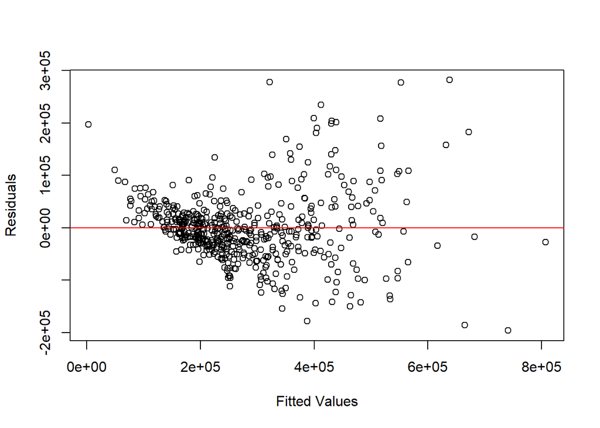

```r
plot(Final_Model_2$fitted.values, resid(Final_Model_2), xlab = "Fitted Values", ylab = "Residuals")
abline(h = 0, col = "red")
```

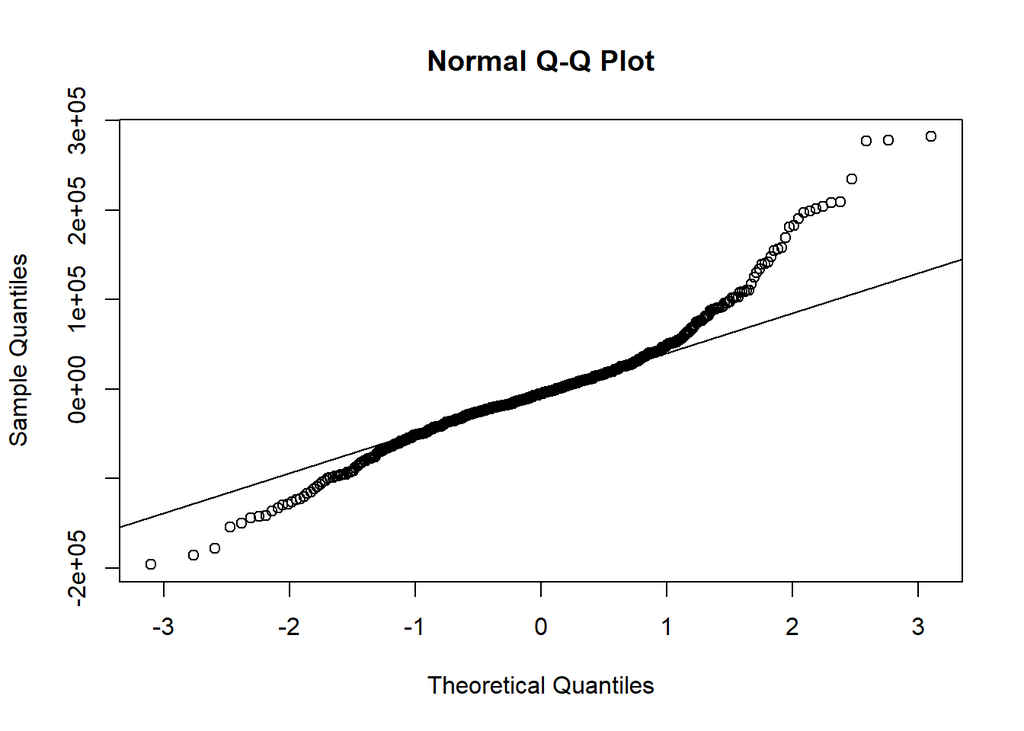

```r
qqnorm(resid(Final_Model_2))
qqline(resid(Final_Model_2))
```